# 20135619 Lee Kang Jin

# assginment 03

# Import package

```python
import random as r
import math
import matplotlib.pyplot as plt
```

# def generatePointCluster(clusterNumber, pointNumber)

: Point 를 생성하는 함수

# def computeDistance(Acordinate, Bcordinate)

: A좌표와 B좌표 사이의 거리를 계산하는 함수

```
 def computeAbsDistance(pointA, pointB) , (상위 함수를 위해서 만든 함수 A점과 B점사이 거리 계산)
```

# def labelInit(clusterNumber, cordinateList):

: label list 초기화 함수 (label은 점들이 속해있는 소속을 의미함)

```
 def randInitValOut(clusterNumber) ,     (상위 함수를 위해서 만든 랜덤출력 함수)
```

# def computeCenter(clusterNumber, cordinateList, labelList)

: label에 따른 평균으로 Center 값 측정 함수

```
 def average(list) ,                      (상위 함수를 위해서 만든 평균값 출력함수)
```

# def labelchange(clusterNumber, cordinateList, center, labelList)

: center에서 가까운 거리의 점들의 label을 바꿔주는 함수

# def computeEnergy(dataList)

: label이 바뀔 때마다 Energy를 측정하는 함수

# def printData(cordinateList, labelList, center)

: label과 center를 시각화 해주는 함수.

# Detail Description

## def generatePointCluster

#### INPUT : clusterNumber : 그룹화 갯수 , pointNumber : 점의 개수

#### OUTPUT clusterNumber*pointNumber 만큼의 좌표

```python
def generatePointCluster(clusterNumber, pointNumber):  # pointNumber * clusterNumber 만큼의 데이터를 생성한다.
    randomCordinateList = []

    for j in range(clusterNumber):
        for i in range(pointNumber):
            randomNumberX = r.randrange(1, 100) / 100
            randomNumberY = r.randrange(1, 100) / 100
            randomCordinateList.append([randomNumberX, randomNumberY])

    return randomCordinateList  # (x,y) list
```

## def computeDistance(Acordinate, Bcordinate)

#### INPUT : X, Y 좌표

#### OUTPUT : X, Y 거리

$computeDistance(x,y) = \sqrt{x^2+y^2}$

$x = x1-x2$ (computeAbsDistance function)

```python
def computeDistance(Acordinate, Bcordinate):  # root ((x1-x2)^2 + (x1-x2)^2)

    # x좌표 계산
    xdistance = computeAbsDistance(Acordinate[0], Bcordinate[0])
    ydistance = computeAbsDistance(Acordinate[1], Bcordinate[1])
    return math.sqrt(xdistance * xdistance + ydistance * ydistance)
```

```python
def computeAbsDistance(pointA, pointB):     #|(Xa - Xa)|
    if (pointA < pointB):
        return pointB - pointA
    elif (pointA > pointB):
        return pointA - pointB
    else:
        return 0
```

## def labelInit(clusterNumber, cordinateList)

#### INPUT : clusterNumber : 그룹화 갯수 , cordinateList : 모든 점들 리스트

#### OUTPUT labelList : 랜덤으로 label이 적혀진 리스트

```python
def randInitValOut(clusterNumber):  # randomly initialise.
    return r.randrange(0, clusterNumber)
```

```python
def labelInit(clusterNumber, cordinateList):
    labelList = []

    for i in range(len(cordinateList)):
        labelList.append(randInitValOut(clusterNumber)) #random하게 리스트의 값을 대입.

    return labelList
```

## def computeCenter(clusterNumber, cordinateList, labelList)

#### INPUT : clusterNumber : 그룹화 갯수, cordinateList :모든 점들 리스트 , labelList :점들의 label 리스트

#### OUTPUT : label에 따른 center

$Average(xlist) = \sum_{k=1}^n{x_n}$/n

```python
def average(list):           #평균값 구하기
    x = 0
    for i in range(len(list)):
        x = x + list[i]

    return x / len(list)
```

```python
def computeCenter(clusterNumber, cordinateList, labelList):          # center 구하기
    center = [[0 for j in range(2)] for i in range(clusterNumber)]   #[[0,0],[0,0] ...] 형식 초기화
    dataLen = len(cordinateList)

    x = [[] for i in range(clusterNumber)]
    y = [[] for i in range(clusterNumber)] # [[].[].[] ..] 형식으로 초기화

    for i in range(dataLen):

        for j in range(clusterNumber):

            if (labelList[i] == j):  # 라벨에 따라서 x,y 들을 집어넣음

                x[j].append(cordinateList[i][0])           #라벨이 j인경우 x[j]번째 리스트에 입력
                y[j].append(cordinateList[i][1])

    for k in range(clusterNumber):

        center[k][0] = average(x[k])                       #x[k]
        center[k][1] = average(y[k])

    return center
```

## def labelchange(clusterNumber, cordinateList, center, labelList)

#### INPUT clusterNumber : 그룹화 갯수 , cordinateList : 모든점 리스트, center : 현재 center 값, labelList :현재 label list

#### OUTPUT labelList : 바뀐 labe list , totaldistanceList : 각 점들과 center간의 최소값들을 모은 리스트

```python
def labelchange(clusterNumber, cordinateList, center, labelList):
    distanceList = []
    totaldistanceList = []
    for i in range(len(cordinateList)):

        for j in range(clusterNumber):
            distanceList.append(computeDistance(center[j], cordinateList[i])) #center와 점들간의 거리를 구함.

        totaldistanceList.append(min(distanceList))                           # 거리가 작은 값들을 totaldistance list에 넣음.
        labelList[i] = distanceList.index(min(distanceList))                  # 거리가 가장 작은 값에 해당하는 라벨을 갱신함.
        distanceList = []

    return labelList,totaldistanceList
```

## def computeEnergy(dataList)

#### INPUT dataList : center와 점들 간의 거리중 가장 작은 값들을 모아놓은 리스트

#### OUTPUT energy: 각 최소값들의 제곱의 합

$Energy(datalist) = \sum_{k=1}^n{(x_n)^2}$

```python
def computeEnergy(dataList):
    # sum(center - dataList 에서 min)^2
    energy = 0
    for i in  range(len(dataList)):
        energy = energy + dataList[i]*dataList[i]

    return energy
```

## def printData(cordinateList, labelList, center)

#### INPUT cordinateList : 모든 좌표 리스트, labelList : label list , center : 현재 center 값

#### OUTPUT : 시각적 효과를 위해 R / G / B 를 사용한 3개의 그룹을 예시로 프린트.

#### 까만점은 각각 R, G, B 그룹에 해당하는 Center

#### labelChange 가 진행이 될 떄 마다 한번 출력해줌.

```python
def printData(cordinateList, labelList, center):
    x = [[], [], []]
    y = [[], [], []]

    for i in range(len(cordinateList)):
        for j in range(3):

            if (labelList[i] == j):
                x[j].append(cordinateList[i][0])
                y[j].append(cordinateList[i][1])

    plt.scatter(x[0], y[0], label="samples", color='r', marker='o')
    plt.scatter(x[1], y[1], label="samples", color='g', marker='o')
    plt.scatter(x[2], y[2], label="samples", color='b', marker='o')

    for i in range(len(center)):
        plt.scatter(center[i][0],center[i][1], label="samples", color='black',marker='o')

    plt.show()
    return 0
```

# Main 함수

초기화 값 : cluster number = 3 point = 100

계속해서 가장 가까운 center로 label을 변경 center가 변화가 없으면 중지함.

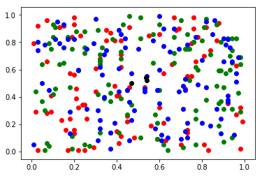

```
Energy: 44.856123271381335
```

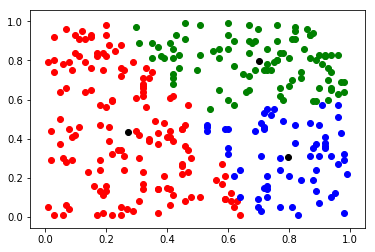

```
Energy: 21.36247068367897
```

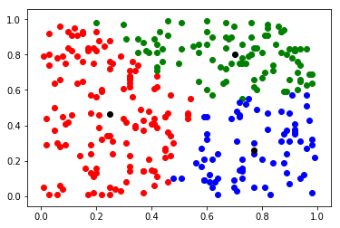

```
Energy: 20.830028639989713
```

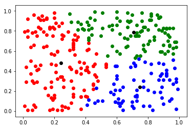

```
Energy: 20.573585979435357
```

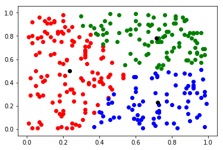

```
Energy: 20.38477421274926
```

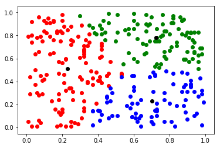

```
Energy: 20.22204372866954
```

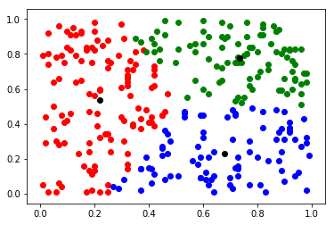

```
Energy: 19.927616887863138
```

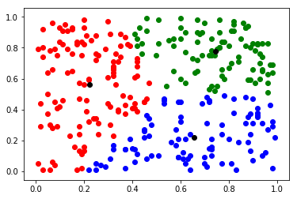

```
Energy: 19.660914193411173
```

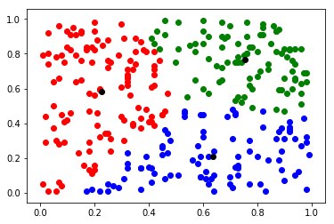

```
Energy: 19.513268675721566
```

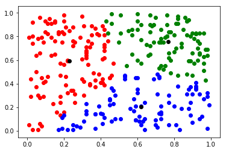

```
Energy: 19.375403967249675
```

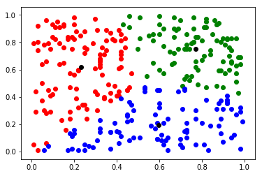

```
Energy: 19.091464555213555
```

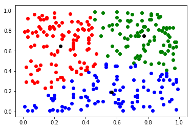

```
Energy: 18.80547926934773
```

[6 more figures not shown]

```
Energy: 17.89196177408177
```

```python
if __name__ == "__main__":

    clusterNumber = 3
    Point = 100
    cord = generatePointCluster(clusterNumber, Point)        #점들 초기화
    label = labelInit(clusterNumber, cord)                   #label 초기화
    disList = []
    energy = 0
    center = computeCenter(clusterNumber, cord, label)      # 첫 center 계산
    befocenter = []

    while (befocenter != center):                          # center가 변화가 없으면 중지.
        printData(cord, label,center)                      # 해당 그룹의 색깔별로 좌표위에 출력
        befocenter = center
        label,disList = labelchange(clusterNumber, cord, center, label)  #가장 가까운 center로 label 변경
        energy = computeEnergy(disList)
        print( "Energy: " + str( energy ) )                              # energy 출력
        center = computeCenter(clusterNumber, cord, label)               # center 다시 계산
```

# Git link https://github.com/LeeKangJin/assignment03

깃허브 과제 제출은 마감일이 지난 뒤에 업로드.